# **2019年4月乘用车市场日系逆势上扬分析解读**

作者：吴智军

2019年5月20日

国内乘用车市场经过29年的持续上涨，2019年迎来了市场的寒冬，在日趋激烈的竞争中市场格局多元复杂，为保持市场竞争力各主机厂产品布局更细分化，更新换代速度日益缩短。然而，在市场份额日趋饱和的状态下，随着春节后官降第一枪的打响，蝴蝶效应席卷整个乘用车市场，我们通过4月销量数据纵览和分析市场呈现的状态。  
2019年4月,销量排名TOP5的品牌依次是一汽-大众、上汽大众、上汽通用、吉利汽车和东风日产，值得注意的是吉利作为唯一自主品牌在激烈的竞争环境下杀入TOP5竞争力凸显，这主要归功于 1、产品质量的不断提升。2、市场精耕细作，3、产品布局不断丰富，2018至2019年新上市产品达12款之多，且在品牌高端化的道路上布局领克品牌，4月WTCR世界赛事中领克03作为国产品牌进入赛事并取得名次实属实力的上升、其次推出几何A等纯电动轿车，吉利能在一片红海中扩张市占率实属不易。

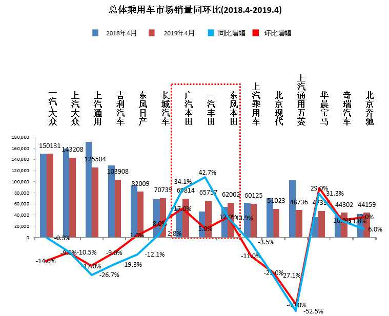

|  | 车企 | X2019年4月 | X2018年4月 | 单月同比 | X2019年累计 | X2018年累计 | 累计同比 |
| --- | --- | --- | --- | --- | --- | --- | --- |
| 1 | 一汽大众 | 150131 | 150,549 | -0.28% | 583,619 | 677,527 | -14% |
| 2 | 上汽大众 | 143208 | 160,010 | -10.50% | 611,105 | 673,068 | -9% |
| 3 | 上汽通用 | 125504 | 171,162 | -26.68% | 552,432 | 662,339 | -17% |
| 4 | 吉利汽车 | 103908 | 128.817 | -19.34% | 470,496 | 515,113 | -9% |
| 5 | 东风日产 | 82009 | 93,306 | -12.11% | 345,991 | 342,155 | 1% |
| 6 | 长城汽车 | 70739 | 68,835 | 2.77% | 318,085 | 293.721 | 8% |
| 7 | 广汽本田 | 69814 | 52,050 | 34.13% | 255,994 | 218,701 | 17% |
| 8 | 一汽丰田 | 65757 | 46,081 | 42.70% | 244,696 | 232,684 | 5% |
| 9 | 东风本田 | 62002 | 54,417 | 13.94% | 234,883 | 210,509 | 12% |
| 10 | 上汽乘用车 | 60125 | 62,290 | -3.48% | 216,427 | 244,127 | -11% |

[output cut: 5 more lines]

**数据来源：乘联会（2019年4月）博睿盛伦国际咨询整理**

然而，在一片呈两位数下降的增长率表现中，日系品牌却逆势上扬，在同比情况下，广汽本田、一汽丰田和东风本田均出现销量回升情况，其中增幅最大的是一汽丰田，增幅达42.7%，为何日系会有如此市场表现，我们将针对四大日系品牌逐一分析，观察和梳理逆势上扬的主要原因。

### **一、一汽丰田FTMS洞察分析**

通过对国内乘用车市场冷静的思考与洞察，笔者认为一汽丰田未来在市场布局上将逐步缩减中大型SUV细分市场份额，进一步进行产能的整合与优化，资源倾斜以提升B级车市场竞争力，主力轿车产品体系向更年轻化转型，深耕混合动力新能源车，紧凑型SUV一改固有外观新产品逐步向“硬”的方向转移，在潜力市场开发方面结合新业态，切入网约车市场寻求新的利润增长点。抢占市场方向活跃在竞争最激烈的区域内厮杀，传统燃油车型渗透河南地区而新能源则渗透广东地区以来稳固日系四大霸主之一的市场地位。

##### **1.1-普拉多让位亚洲龙**

一汽丰田在逐步释放中大型SUV的市场份额，转型的典型特征是普拉多将为亚洲龙让位，并且在国六排名标准政策的限制下，国内市场普拉多3.5L车型将计划于2020年6月正式停产，而将原普拉多产能与四川野马汽车股份有限公司合作生产基于TNGA平台打造的亚洲龙，预计产能为10万辆/年，其中混动版车型不低于5000辆/年。大有王者归来之势。 主打中高端B级市场的亚洲龙在今年3月21日上市，尊贵版官方定价24.48万，新车一经上市订单就呈直线上升状态，这个价格加之日系的产品质量，结合丰富的配置完全不逊色于目前市场任何B级车型，在2019年严峻的车市环境下，亚洲龙好似冬日里的一把火，这为一汽丰田提振市场信心起到重要作用。

##### **1.2-紧凑型SUV塑造硬汉产品形象**

在市场促销方面，RAV4主要向河南地区渗透，4月中旬，以“展示青春的不羁和无束，寻找、突破和发现全新”为主题的河南文化之旅活动如火如荼展开，此间经历了少林寺，龙门石窟等多处非物质文化遗产景区，进一步塑造和提升产品市场形象。未来，就RAV4来看，在刚结束不久的上海车展上亮相了第五代RAV4，最直观的印象是一改“居家买菜风”的外观风格，整体线条更加刚硬，硬派越野车的形象被再次重塑，与此同时，在竞合关系层面，一汽丰田将与广汽丰田结成战略联盟，进一步寻求市场份额的最大化，据悉，第五代RAV4将不再属于一汽丰田的专属，丰田将采取双车战略，全新RAV4由一汽丰田与广汽丰田同时生产销售，就像奕泽与C-HR一样。

##### **1.3-从保守向年轻、时尚的转变**

作为一汽丰田主力车型的威驰也在大刀阔斧的改变以迎合市场的需求，首款两厢威驰FS上市并向更年轻化的方向进化，FS一经上市三月销量就达3006台，同比增长2.73%，而旧款威驰则以3-3.5万的降幅大力促销为FS腾挪出更多的市场空间，从精耕细作的管理中获取的市场红利正在逐渐显现出来。 素有家轿之王之称的卡罗拉也将迎来第12代车型，新车仍基于TNGA架构打造，提供1.2T和1.8L混动两种动力选择，将今年于8-9月份上市。对标车型挤占英朗份额。

##### **1.4-深化混合动力产品布局**

一汽丰田在产品组合层面带来了卡罗拉双擎及双擎E+，混动逐步代替燃油车型，新能源结构布局非常明显。同时，在拓宽市场增长潜力和寻找新的增长点方面，卡罗拉子不断渗透网约车市场，开辟新的蓝海，卡罗拉双擎在网约车市场中累计销售优秀。4月17日，一汽丰田卡罗拉双擎E+首批VIP客户交车仪式在深圳宝安大兴丰田经销店举行。此次，一汽丰田向深圳仁林锦江汽车服务有限公司交付60台卡罗拉双擎E+新车，这也标志着一汽丰田“新能源1号车”上市仅一个月，就成功在出行市场打开了局面。

### **二、东风日产洞察分析**

##### **2.1-服务打造让客户安心消费**

随着汽车行业进入存量时代，售后服务体验与企业增长之间的关系愈加明显。4月24日，东风日产发布公告，全面升级“三包”政策，降低政策门槛，让消费者安心购车及用车，免除后顾之忧。根据政策细则，自2019年4月24日~2019年12月31日，凡购买东风日产全系家用汽车产品（含途达），均可在原有“三包”政策的基础上，额外享受“7天质保换新”及“首、二保不受限”服务。

在现行的“三包”法规中，“退换车”条件的达成相对严格，而东风日产此次在国家“三包”退换车政策之外，作出“7天质保换新”承诺，加码现有条款，承诺客户车辆在购买7天内（以发票日期为准），国家标准范围内的主要零部件出现特定品质问题，均可申请免费更换同型号、同级别、同颜色的新车。这表明东风日产正和经销商共同打造服务升级生态体系，提高客户满意度，赋能经销商经营收益。

### **三、广汽本田洞察分析**

##### **3.1-雅阁、凌派成为拉动上涨的主力**

雅阁作为国内乘用车中高级轿车销量冠军，在4月份继续保持了这一增长势头，仅混动版车型就售出2,267辆，同期相比上涨34.1%。此外，广汽本田旗下飞度和凌派均交出了4月份销售过万辆的成绩单。目前雅阁每月超过2万台的销量，凌派车型的月销量也超过1万辆，两款车型都是广汽本田的支柱车型。广汽本田凭借两款车型年轻化的定位，以及独有的产品优势，不断扩大市场份额，继续稳居细分市场前列。

##### **3.2-奥德赛锐混动领衔**

广本奥德赛推出MPV细分市场首款混动车型，奥德赛锐混动的到来，将本田在MPV细分市场上的地位进行了完善，锐混动价格跟燃油版基本相同而其独树一帜的卖点和产品体验，才是这款MPV最为重要的核心竞争力。

##### **3.3-深化数字化精准营销**

2019年广汽本田整体营销层面采取“一车一策”的营销策略，针对不同车型的特点和不同用户群开展更加丰富、多元的营销活动。也在非常积极地精准找到潜在客户，开展数字营销。

##### **3.4-加速电动化进程**

未来广汽本田也将在产品方面加速电动化的进程，未来混动车型比例也会越来越扩大，将会继续导入SPORT TURBO、SPORT HYBRID动力的新车型，进一步强化产品矩阵。

### **四、东风本田洞察分析**

##### **4.1-享域配合思域的双子星战略**

4月10日，东风本田全新紧凑型家用轿车享域正式上市，与思域并肩构成双子星战略格局，享域整车定位略低于思域，主打入门级家轿。共发布四款车型，价格从9.98万到13.68万元不等，享域一经上市便直接抢占朗逸和卡罗拉的市场份额，作为一款中国特供车型，以大空间舒适性卖点获得了更多家庭用车的青睐，另外，享域的另一重重要身份是凌派的姊妹车型。 5月17日，新款思域上市或将进一步助推东本的市场表现，新款思域的到来将继续满足年轻消费者对于东风本田旗下轿车的购车需求，也对旗下的产品阵营继续一次更新。

##### **4.2-CR-V“机油门”事件回暖**

受2018年1.5T车型发动机机油增多事件的影响，CR-V一度被推上舆论的风口浪尖，一段时期内严重影响了该产品的市场表现，随着事件的逐步平息进入2019年3月CR-V以13,970辆的终端销量，重回国内SUV市场销量前十。其中，混动版CR-V终端销量为2,115辆，同比增长183.5%。据悉，4月12日东风本田第三工厂建成投产，一期年产能12万辆，投产的首款车为CR-V。CR-V在一定程度上成为东风Honda的定海神针，凭借自身之力推动并造就着“小市场、大份额”的行业神话。

##### **4.3-新能源加持，坚持SUV混动布局**

东风Honda将首款电动车安排在今年发布和上市，不仅是出于满足市场需求，更是基于自身实际发展状况特别是生产准备上的严谨考虑。 第三工厂的“适时”投产，实现了车型与产能二者之间的无缝衔接，将有效助力东风Honda在新能源汽车领域行稳致远；从更深层次角度来讲，东风Honda将由此进入一个全新的EV时代。而新增的12万辆产能不仅有助于解决困扰东风Honda多年的产能瓶颈，更有望助力东风Honda冲刺百万辆销量目标，跻身国内一线主流车企，在产能进一步释放后，预计东风本田下一步将加快更多海外车型的导入，以及新能源产品的研发。

##### **4.4-产能持续释放**

四月，历时两年多建造起来的东风本田武汉第三工厂12万台年产能正式投产，标志着东风本田紧缺了多年的产能终于得到了一定程度的释放。 在第三工厂投产之前，东风本田第一、第二工厂产能合计为51.2万台，而2018年东风本田销量达到72万辆，产能利用率超过了130%。东风本田第三工厂依旧在武汉建立，从开工到目前一期投产仅仅过去了两年半的时间，这已经是目前汽车工厂建设的最快速度之一了，可见东风本田对产能的渴望有多强烈。

### **五、总结与观点**

综合以上对日系在市场寒冬逆势增长的全面剖析，博睿观点如下：1、挤和抢占：商场如战场，无论市场竞争多么残酷，持续的挤占和抢占，总会有品牌被挤下去新品牌挤进来，并逐步取得稳固的市场地位。2、得换购者得天下：市场日趋饱和，换购用户群体扩张和消费成为汽车消费的新态势，从自主到合资，合资到豪华，品牌上升跃迁将成为长期的市场规律趋势，如何在用户跃迁的过程中黏着，绑定以提升客户的消费周期价值是一个新的方向。3、得服务者得天下：产品市场日趋饱和，消费者购买产品更关注消费后续的安心和省事，对汽车这种大宗消费品来说主机厂对品质和服务的承诺若出现纰漏将导致雪崩式的市区溃败。4、重构新的商业模式，开启新的增长方式：智能化、移动出行不断的催生新的市场需求，改变用户对汽车固有的消费观念，品牌寻找并结合新业态，互相渗透，互相融合是新的市场增长驱动力。